#### kilometer’s

a junk space

[研究関連] [R関連] [書評] [その他]

home

### 書評：『最古の文字なのか - 氷河期の洞窟に残された32の記号の謎を解く』

Genevieve von Petzinger(著), 櫻井裕子(訳), 文藝春秋, 2016年 [[link]](https://www.amazon.co.jp/dp/4163905596)

古代人類の残した洞窟壁画において圧倒的多数を占めながら“幾何学記号”と十把一絡げに纏められていた記号群の記録・分類・整理を通して論じられる記号源論はとてもエキサイティングでした。

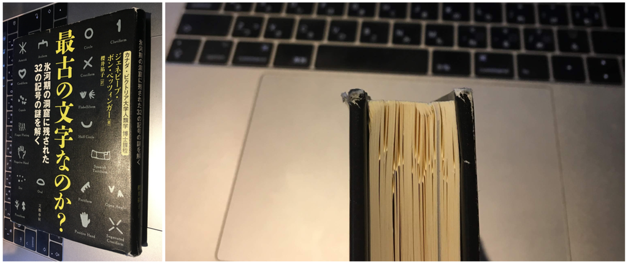

筆者らの手により浮かび上がった重要な指摘は、ヨーロッパ地域に残る最古の壁画シンボルは人類がヨーロッパに到達したのとほぼ同時か直後の物だという事です。従って、遅くとも出アフリカまでにホモ・サピエンスは(少なくとも単純な)言語を用いていた事が示唆されますが、これはこれまでの通説からしたら驚くべき事だと言えそうです。氷河期(これは学術的な用語ではないですが)における厳しい自然環境において、生存のための創意工夫や異なる人類集団の合流、あるいはその後の温暖化に伴う人口＝群サイズの増加が爆発的な知の創造をもたらした、という通説を覆す可能性があるからです。

この言語の起源というのはどうにも魅力的なテーマです。言語とは何かという問題は、ヒトとは何かという問題に漸近しているような気すらします。現代の地球に生息しているホモ・サピエンスという生物種は言語を用いて自己の内部状態を外部に固定し、他者(あるいは自分自身)に対して伝達しています。本書において文字は「耐久性のある面に書かれた、視覚的で慣習化された記号を利用する、相互コミュニケーションのシステム」として定義されていますが、この定義に準ずると、言語とは「慣習化された記号を利用する相互コミュニケーションのシステム」を指します。筆者も一部指摘していますが、この慣習化という概念には重要な問題を含んでいるように思います。この本では、「音声言語で表せる情報を何でも図形を使って表させること」という書き方をしています。すなわち、この本では(単純かもしれないけれど少なくとも統語構造を持つ)音声言語の発達があった後に、それを表す図形記号そして文字言語の発明があったという立場に立っているようです。僕はそれにはあまり合意しません。

音声による情報伝達はヒト以外の霊長類を含む多くの動物種において観察されます。それは例えば「敵が来るから逃げろ」「餌を見つけたから集まれ」「僕はここにいるから見に来て」といったといった動詞的(S.ミズン風に言えば操作的[1])な情報です。「逃げろ」という音声を発する際には他者がその音声に対してどう反応するのかという推定が必要ですので、自己の経験が参照され、群において共有される音声シンボルが用いられると想像されます。これが第一段階とします。次はサル類や特に大型霊長類において顕著ですが、群サイズが大きくなるにつれて個体間の関係(敵対, 親和, 中立, 上位, 下位, etc…)を相互に示す手段として音声記号が用いられる段階です。このステージでは自己の内部状態を符号化する事それ自体が目的になっているという意味で言語に近い音声使用といえます。こうした進化の親戚たちによる音声使用を観察していると、ヒト亜族が分岐した時には、恐らくこの状況に近い音声コミュニケーションを獲得していたのではないかと考えられます。しかし、この段階にあった言語は、あくまで対他者への情報伝達手段であり、自己の主観的世界の全てを表す事は無かったのではないでしょうか。現在のヒトの言語はこの段階から更に飛躍があります(第三段階)。それは自意識と呼ばれる作用のおおよそ全てを言語に立脚している事です。知覚可能なおおよそ全ての情報に対して対応する言語記号があるため、自己の内部で閉じた擬似世界を言語的に構築し展開する事ができるというのは、ヒトにとってはあまりにも当たり前な言語使用ですが、他の動物種の音声使用を参照すると、これはほとんど異常な目的外使用で、いわば外れ値です。

この最後の飛躍において、音声記号それ自体のみならず、図形記号の複雑化が相補的に作用したのではないかというのが僕の考えです。音声記号だけでは伝達できない情報を図形記号として書く。図形記号が共有されるようになるとそれに音声記号が割り当てられる。それでも表しきれない事を新たな図形記号で書く。それが共有されて新たな音声記号が生まれる。この双方向的な複雑化のループは、世界を際限なく情報化していくという意味で、現在のヒト言語の起源を説明するシナリオとして魅力的です。「似たものは近い記号で表す」という定常性に従って世界を整理するというバイアスが複雑化ループに加えられていたとしたら徐々に統語的構造が生まれてきそうです。そうした世界が言語記号に分解されていく過程で、いわば副作用として自己の内部に擬似世界が構築され、それが自意識と呼ばれているのではないかと思うわけです。

となると、戻りますが、筆者の提示する先に統語構造を持った音声言語ありきの文字言語進化というプロセスとはどうも食い合わせが悪いなと感じる次第です。いずれにせよ筆者の指摘する通り、ヨーロッパ以外での特にアフリカ・アジアにおける古人類痕跡の発掘が着目されていることから、この分野の常識はここ数年〜10年ぐらいのスパンでどんどん変わっていくのだろうなという予感がします。

[1] 以前紹介した『歌うネアンデルタール』を参照のこと

2019年1月6日